# Pipelining

Aidan Morrison

29/05/2019

## What is a pipeline?

- Focus on pipeline for training and deploying machine-learning models
- Less about moving data than transforming it into desired format
- Still generally expected to ‘flow’ (be updated)

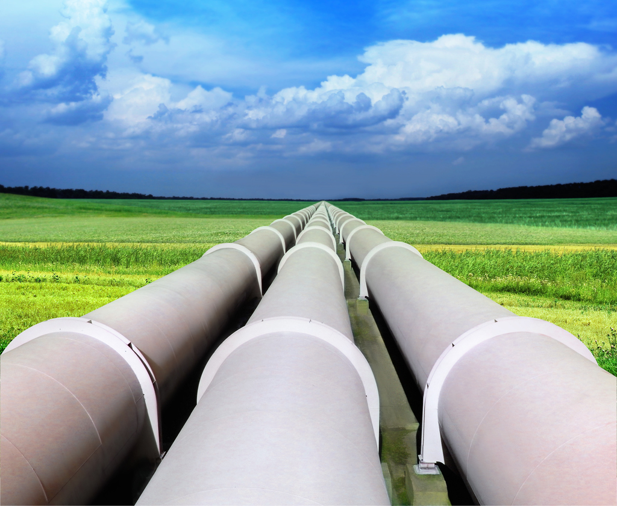

## Why do we need a pipeline?

- Data at source is never ready for use in a model
- New data will arrive
- Need a *repeatable* process to get it ready
- Want *flexibility* to engineer new features, exploit new data

[figure not shown]

## What sorts of things are in a pipeline

- creating new variables
- naming variables/levels
- joining data from different sources
- type coercion (dates, factors, booleans, numbers)
- aggregation
- summarisation
- time-binning
- filtering (missing values, unrealistic values)
- imputation
- flagging (of imputed values, coercion etc)
- reshaping (spreading, gathering, one-hot-encoding)

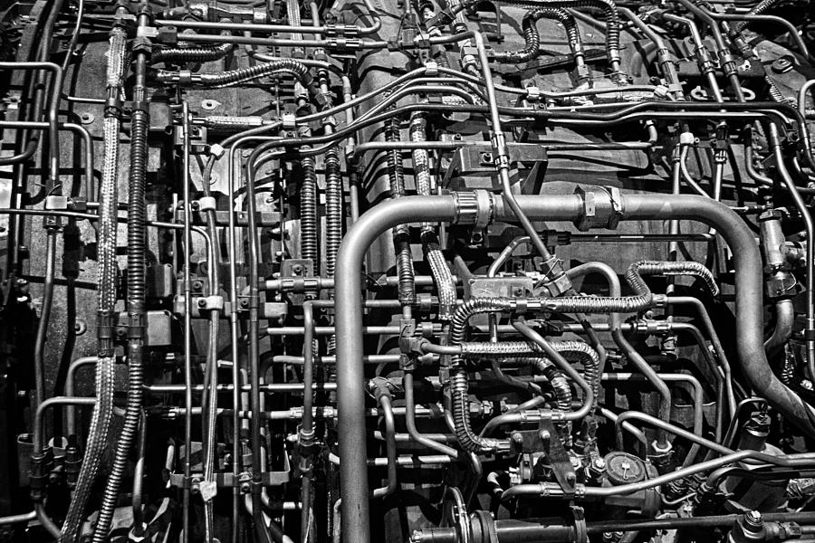

Image Credit: Austin Troya

## How can this get hard?

In so many ways, it’s crazy…

- When to join pipes
- When to narrow pipes
- When to insert reservoirs

```r
### a join
df <- df %>% left_join(other_df, by = "key")

### a narrowing
df <- df %>%
  select(-bad_variable) %>%
  filter(some_variable > 0)

### a reservoir
sqlSave(con, df, "TableName", rownames = F, append = T)
```

## How can it get REALLY hard…

- The special problem of water-hammer

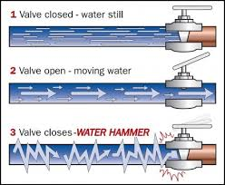

## Let’s start with how it can be easy…

There’s the obvious things:

- clean, well-named data
- not too much data
- no missing data
- you know exactly what the use case is
- no-one else will need the processed data for something else

But the key advantage is:

- Each observation is static (doesn’t evolve, order/history doesn’t matter)

## ftplanes

```r
ftplanes <- read_csv("/Users/aidanmorrison/fighterplanes/intdata/ftplanes.csv")
head(ftplanes)
```

```
## # A tibble: 6 x 29
##   name  Bombs_kg Cruise_speed_kmh Dry_thrust_kg Empty_weight_kg
##   <chr>    <dbl>            <dbl>         <dbl>           <dbl>
## 1 AD S…       NA               NA            NA             NA
## 2 ADA/…       NA               NA            NA          17277.
## 3 Aerf…       NA               NA            NA           2400.
## 4 Aero…       NA               NA            NA           2318.
## 5 AIDC…       NA               NA            NA             NA
## 6 Airc…       NA               NA            NA            616
## # … with 24 more variables: Gross_weight_kg <dbl>, Guns_mm <dbl>,
## #   Height_m <dbl>, Length_m <dbl>, Loaded_weight_kg <dbl>,
## #   Max._takeoff_weight_kg <dbl>, Maximum_speed_kmh <dbl>,
## #   Powerplant_kg <dbl>, Powerplant_kW <dbl>, Powerplant_m <dbl>,
## #   Range_m <dbl>, Rate_of_climb_m <dbl>, Rate_of_climb_ms <dbl>,
## #   Service_ceiling_m <dbl>, Thrust_with_afterburner_kg <dbl>,
## #   Wing_area_m <dbl>, Wing_area_m2 <dbl>, Wing_loading_kg <dbl>,
## #   Wing_loading_m2 <dbl>, Wingspan_m <dbl>, country <chr>, year <dbl>,
## #   number <dbl>, status <chr>
```

## Cutting down ftplanes

```r
my_skim <- skim(ftplanes) %>%
  filter(stat == "complete")
good_vars <- my_skim %>%
  filter(value  > 350) %>%
  pull(variable)
ftplanes_slim <- ftplanes %>%
  select(good_vars)
skim(ftplanes_slim)
```

```
## Skim summary statistics
##  n obs: 646
##  n variables: 13
##
## ── Variable type:character ────────────────────────────────────────────────────────────────────────────────
##  variable missing complete   n min max empty n_unique
##   country       0      646 646   4  29     0       41
##      name       0      646 646   6  39     0      646
##    status       0      646 646   7  11     0        6
##
## ── Variable type:numeric ──────────────────────────────────────────────────────────────────────────────────
##           variable missing complete   n     mean      sd      p0     p25
##    Empty_weight_kg     112      534 646  3381.3  4317.86  287.12  878.04
##           Height_m     108      538 646     3.38    1.01    1.52    2.74
##           Length_m      63      583 646     9.66    4.21    3.35    7.01
##  Maximum_speed_kmh     290      356 646   457.78  343.12  112.97  225.31
##             number       0      646 646   717.34 2608.73    0       1
##      Powerplant_kW     241      405 646   511.34  437.53   37     172
##  Service_ceiling_m     171      475 646 10161.27 4229.06 1200    7005
##       Wing_area_m2     116      530 646    26.83   13.61    4.73   19
##         Wingspan_m      65      581 646    12.26   41.1     5.79    9.14
##               year       5      641 646  1937.33   18.91 1913    1924
##      p50      p75     p100     hist
##  1453.99  4048.33 27604    ▇▂▁▁▁▁▁▁
##     3.05     3.83     8.3  ▁▇▃▂▁▁▁▁
##     8.17    10.9     30.97 ▃▇▂▂▁▁▁▁
##   327.25   592.34  2444.64 ▇▃▁▁▁▁▁▁
##    10      228.75 33984    ▇▁▁▁▁▁▁▁
##   380      678.59  2238    ▇▇▃▂▁▁▁▁
##  9450    12425    27400    ▁▇▇▅▃▂▁▁
##    23.41    30.01   167    ▇▅▁▁▁▁▁▁
##    10.06    11.58   999.74 ▇▁▁▁▁▁▁▁
##  1934     1944     2011    ▇▇▇▂▁▁▁▁
```

## Modeling most built planes

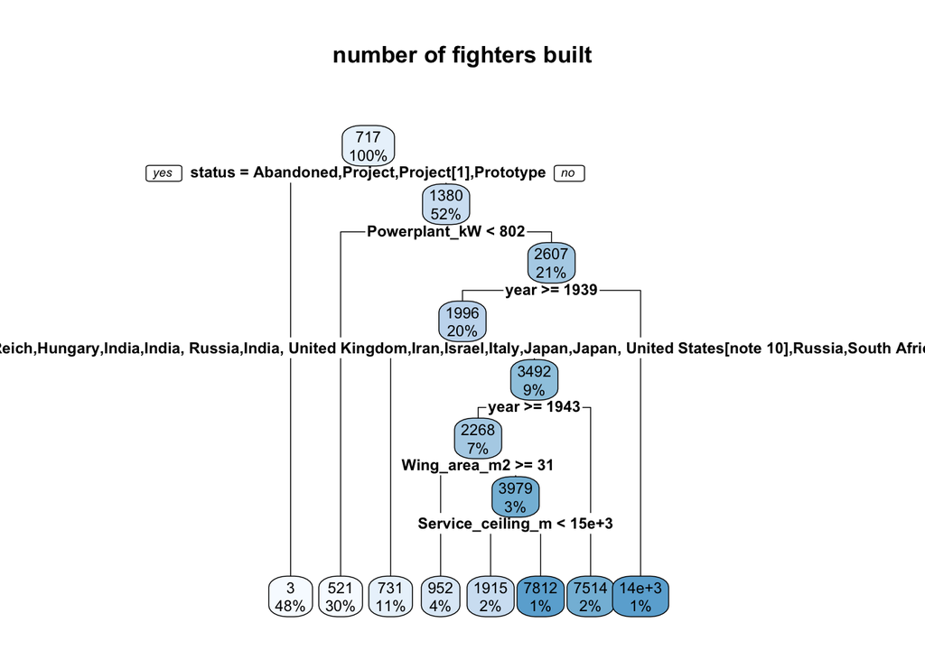

```r
df_train <- ftplanes_slim
mod <- df_train %>%
  select(-name) %>%
  rpart(formula = number ~.)
rpart.plot(mod, cex = 0.7, main = "number of fighters built")
```

## How did the model go?

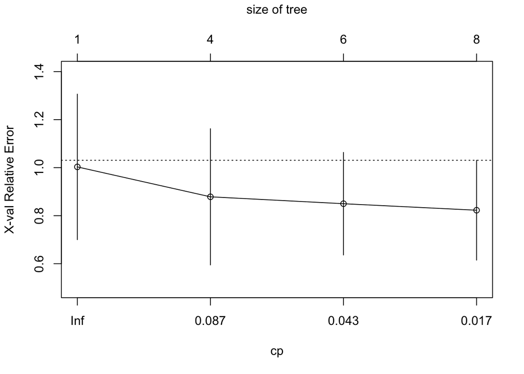

```r
plotcp(mod)
```

## A possible way to improve it - engineer a new feature

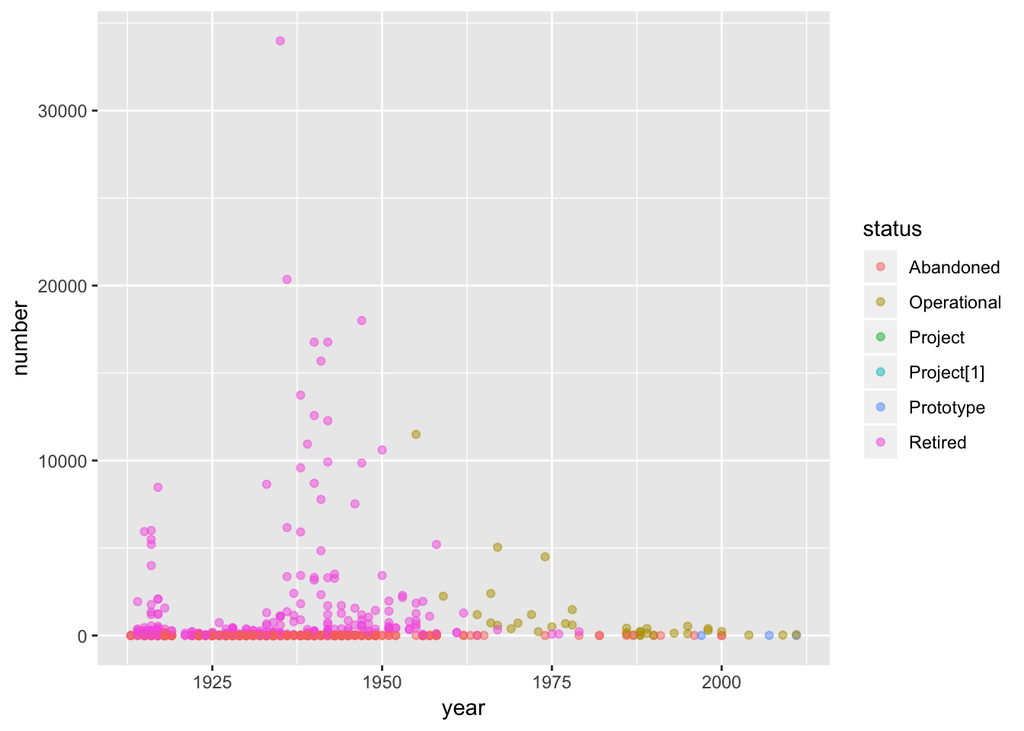

```r
ftplanes_slim %>%
  #filter(country %in% topcountries) %>%
  ggplot(aes(x = year, y = number, col = status))+
  geom_point(alpha = 0.5)
```

```r
df_train <- ftplanes_slim %>%
  mutate(ww = case_when((year %in% c(1914:1918) | year %in% c(1939:1945)) ~  TRUE,
                        TRUE ~ FALSE))
df_train %>%
  select(year, name, ww) %>%
  head()
```

```
## # A tibble: 6 x 3
##    year name                                    ww
##   <dbl> <chr>                                   <lgl>
## 1  1915 AD Scout                                TRUE
## 2    NA ADA/HAL Advanced Medium Combat Aircraft FALSE
## 3  1958 Aerfer Ariete                           FALSE
## 4  1939 Aeronautica Umbra Trojani AUT.18        TRUE
## 5  1989 AIDC F-CK-1 Ching-kuo                   FALSE
## 6  1915 Airco DH.1                              TRUE
```

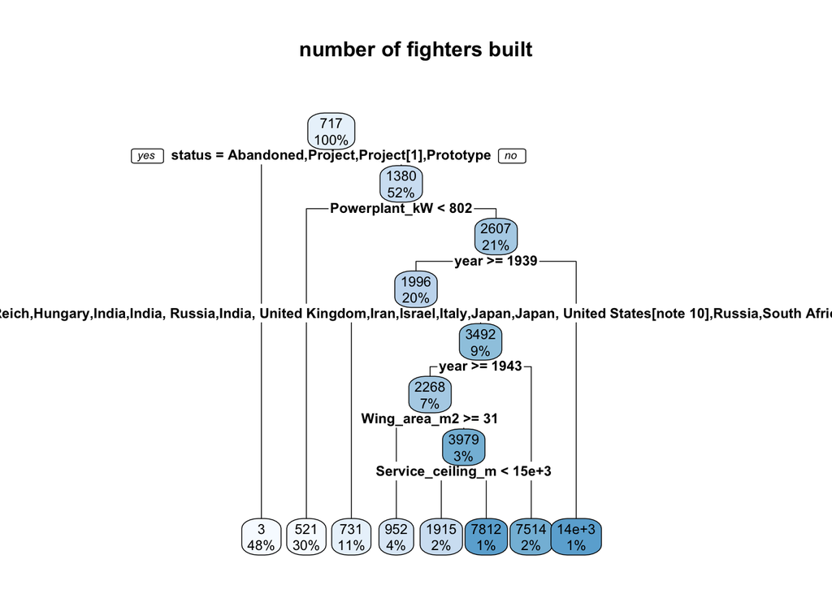

```r
mod <- df_train %>%
  select(-name) %>%
  rpart(formula = number ~.)
rpart.plot(mod, cex = 0.7, main = "number of fighters built")
```

## The new feature might help…

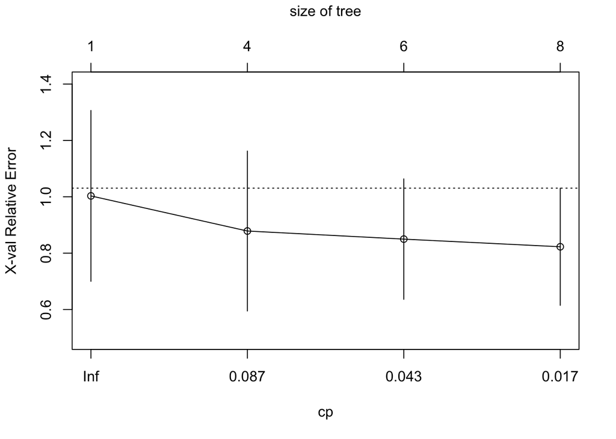

```r
plotcp(mod)
```

Apparently not!

## If we wanted to check properly…

```r
set.seed(99)
df_train <- sample_frac(ftplanes_slim, .7)
trained <- df_train %>% pull(name)
df_test <- ftplanes_slim %>% filter(!name %in% trained)
mod <- df_train %>%
  select(-name) %>%
  rpart(formula = number ~.)
results <- predict(mod, newdata = df_test)
```

We’d get a classic error.

```r
country_summ <- ftplanes_slim %>%
  group_by(country) %>%
  summarise(count = n()) %>%
  arrange(desc(count))

head(country_summ, 15)
```

```
## # A tibble: 15 x 2
##    country                   count
##    <chr>                     <int>
##  1 United States               143
##  2 United Kingdom              131
##  3 USSR                         78
##  4 France                       66
##  5 Italy                        34
##  6 German Empire                32
##  7 Japan                        26
##  8 Czechoslovakia               18
##  9 Germany - 3rd Reich          15
## 10 Germany - Weimar Republic    12
## 11 Netherlands                  11
## 12 China (PRC)                   9
## 13 Russia                        8
## 14 Sweden                        8
## 15 Romania                       6
```

```r
tail(country_summ, 15)
```

```
## # A tibble: 15 x 2
##    country                       count
##    <chr>                         <int>
##  1 Canada                            1
##  2 Chile                             1
##  3 Denmark                           1
##  4 Egypt                             1
##  5 Hungary                           1
##  6 India, Russia                     1
##  7 India, United Kingdom             1
##  8 Japan, United States[note 10]     1
##  9 Latvia                            1
## 10 South Africa                      1
## 11 South Korea                       1
## 12 South Korea, Indonesia            1
## 13 Taiwan                            1
## 14 United States, United Kingdom     1
## 15 Yugoslavia                        1
```

## Perhaps for a different label

Trying a linear model for a physical attribute

```r
df_train <- ftplanes_slim %>%
    select_if(.predicate = is.numeric)
linmod <- df_train %>%
  lm(formula = Maximum_speed_kmh ~.)
summary(linmod)
```

```
##
## Call:
## lm(formula = Maximum_speed_kmh ~ ., data = .)
##
## Residuals:
##     Min      1Q  Median      3Q     Max
## -95.235 -23.594  -2.659  25.073 131.809
##
## Coefficients:
##                     Estimate Std. Error t value Pr(>|t|)
## (Intercept)       -1.643e+04  1.496e+03 -10.982  < 2e-16 ***
## Empty_weight_kg    1.143e-02  4.565e-03   2.504   0.0133 *
## Height_m           3.413e+00  8.992e+00   0.380   0.7048
## Length_m           6.578e+00  4.376e+00   1.503   0.1349
## Powerplant_kW      1.204e-01  1.943e-02   6.197 5.03e-09 ***
## Service_ceiling_m  5.789e-03  2.439e-03   2.374   0.0188 *
## Wing_area_m2      -3.504e+00  7.730e-01  -4.533 1.16e-05 ***
## Wingspan_m        -1.700e-02  4.208e-02  -0.404   0.6867
## year               8.643e+00  7.850e-01  11.011  < 2e-16 ***
## number             3.770e-03  8.630e-04   4.368 2.29e-05 ***
## ---
## Signif. codes:  0 '***' 0.001 '**' 0.01 '*' 0.05 '.' 0.1 ' ' 1
##
## Residual standard error: 41.3 on 154 degrees of freedom
##   (482 observations deleted due to missingness)
## Multiple R-squared:  0.9535, Adjusted R-squared:  0.9508
## F-statistic: 351.2 on 9 and 154 DF,  p-value: < 2.2e-16
```

As it turns out, highly correlated with number and year!

```r
df_train <- ftplanes_slim %>%
    select_if(.predicate = is.numeric) %>%
  select(-year, -number)
linmod <- df_train %>%
  lm(formula = Maximum_speed_kmh ~.)
summary(linmod)
```

```
##
## Call:
## lm(formula = Maximum_speed_kmh ~ ., data = .)
##
## Residuals:
##      Min       1Q   Median       3Q      Max
## -178.714  -32.437   -3.911   24.916  162.771
##
## Coefficients:
##                    Estimate Std. Error t value Pr(>|t|)
## (Intercept)       38.452956  42.376921   0.907    0.366
## Empty_weight_kg    0.007846   0.006089   1.288    0.199
## Height_m           9.433453  11.988877   0.787    0.433
## Length_m          24.199978   5.483046   4.414 1.89e-05 ***
## Powerplant_kW      0.201251   0.024201   8.316 4.22e-14 ***
## Service_ceiling_m  0.017600   0.002949   5.969 1.55e-08 ***
## Wing_area_m2      -6.851342   0.956820  -7.161 2.97e-11 ***
## Wingspan_m        -0.011185   0.056393  -0.198    0.843
## ---
## Signif. codes:  0 '***' 0.001 '**' 0.01 '*' 0.05 '.' 0.1 ' ' 1
##
## Residual standard error: 55.41 on 156 degrees of freedom
##   (482 observations deleted due to missingness)
## Multiple R-squared:  0.9153, Adjusted R-squared:  0.9115
## F-statistic: 240.8 on 7 and 156 DF,  p-value: < 2.2e-16
```

## Engineer some new features, from within an observation

Taking some ratios

```r
df_train <- ftplanes_slim %>%
  select_if(.predicate = is.numeric) %>%
  select(-year, -number) %>%
  mutate(power_weight = Powerplant_kW / Empty_weight_kg,
         length_width = Length_m / Wingspan_m,
         length_height  = Length_m / Height_m,
         power_area = Powerplant_kW / Wing_area_m2)
linmod <- df_train %>%
  lm(formula = Maximum_speed_kmh ~.)
summary(linmod)
```

```
##
## Call:
## lm(formula = Maximum_speed_kmh ~ ., data = .)
##
## Residuals:
##      Min       1Q   Median       3Q      Max
## -136.930  -28.546   -0.307   25.672  202.958
##
## Coefficients:
##                     Estimate Std. Error t value Pr(>|t|)
## (Intercept)       -2.476e+02  1.351e+02  -1.832  0.06885 .
## Empty_weight_kg    2.901e-02  7.386e-03   3.928  0.00013 ***
## Height_m           9.301e+01  4.169e+01   2.231  0.02715 *
## Length_m          -9.917e+00  1.639e+01  -0.605  0.54605
## Powerplant_kW     -6.220e-02  4.657e-02  -1.335  0.18371
## Service_ceiling_m  1.761e-02  2.994e-03   5.882 2.49e-08 ***
## Wing_area_m2      -2.679e+00  1.052e+00  -2.546  0.01190 *
## Wingspan_m         1.690e-02  6.683e-02   0.253  0.80073
## power_weight      -1.124e+02  7.403e+01  -1.518  0.13109
## length_width       1.354e+01  5.764e+01   0.235  0.81454
## length_height      7.891e+01  4.512e+01   1.749  0.08232 .
## power_area         5.303e+00  7.640e-01   6.941 1.05e-10 ***
## ---
## Signif. codes:  0 '***' 0.001 '**' 0.01 '*' 0.05 '.' 0.1 ' ' 1
##
## Residual standard error: 47.6 on 152 degrees of freedom
##   (482 observations deleted due to missingness)
## Multiple R-squared:  0.9391, Adjusted R-squared:  0.9347
## F-statistic:   213 on 11 and 152 DF,  p-value: < 2.2e-16
```

## So what have we possibly concluded?

- Joining: As late as possible and early as necessary, re-assess names
- Narrowing: As early as possible, (provided you save it), ideally in a way that is descriptive rather than hard-coded, but records and can revert to a result
- Reservoiring: Before removing data

## A quick thought on names

(it’s true, there are only two hard things in computer science…)

They probably will have to change…

```r
### Changing Colnames to be safer for data operations
colnames(df_work) <- c(colnames(df_work) %>%
                         str_replace_all("-", "_") %>%
                         str_replace_all("/", "_") %>%
                         str_replace_all("\\(", "_") %>%
                         str_replace_all("%", "percent_") %>%
                         str_replace_all("\\)", "_") %>%
                         str_replace_all(" ", "_") %>%
                         str_replace_all("__", "_") %>%
                         str_replace_all("__", "_"))
```

I tend to use:

- just underscores
- generally avoid capitalisation
- tolerate long names
- include some recogniseable chunk of the ‘original’ name string

## A worked example

```r
### Create two tables reflecting provenance
meta <- ftplanes %>% select(name, country, year, number, status)
specs <- ftplanes %>% select(-country, -year, -number, -status)

### Engineer strictly physical attributes
specs <- specs %>%
  mutate(power_weight = Powerplant_kW / Empty_weight_kg,
         length_width = Length_m / Wingspan_m,
         length_height  = Length_m / Height_m,
         power_area = Powerplant_kW / Wing_area_m2)

### Sort out a sensible prefix to show origin
metanames <- colnames(meta)[-1]
specnames <- colnames(specs)[-1]
colnames(meta) <- c("name", paste0("meta_", metanames))
colnames(specs) <- c("name", paste0("spec_", specnames))

### Cut down to well-populated specs, saving cut
my_skim <- skim(specs) %>%
  filter(stat == "complete")
good_specs <- my_skim %>%
  filter(value  > (nrow(ftplanes)*.55) ) %>%
  pull(variable)
filename <- paste0("good_vars_", Sys.time(), ".rds")
good_specs %>% saveRDS(filename)
specs_slim <- specs %>%
  select(good_specs)

## Save a copy of the full specs
specs %>% write_fst("specs.fst")

## Reduce the number of countries
top_countries <- meta %>%
  group_by(meta_country) %>%
  summarise(count = n()) %>%
  arrange(desc(count)) %>%
  head(10) %>%
  pull(meta_country)

filename <- paste0("top_countries_", Sys.time(), ".rds")
top_countries %>% saveRDS(filename)

meta_lowcard <- meta %>%
  mutate(meta_country = case_when(meta_country %in% top_countries ~ meta_country,
                             TRUE ~ "other"))

### Save the unadultered meta table
meta %>% write_fst("meta.fst")

### Join the (trimmed) tables
df_master <- meta_lowcard %>%
  left_join(specs_slim, by = "name")

### Now to split into train and test, then model, predict
set.seed(99)
df_train <- sample_frac(df_master, .7)
trained <- df_train %>% pull(name)
df_test <- df_master %>% filter(!name %in% trained)
mod <- df_train %>%
  select(-name) %>%
  rpart(formula = meta_number ~.)
results <- predict(object = mod, newdata = df_test)
print(rmse(df_test$meta_number, results))
```

```
## [1] 2226.011
```

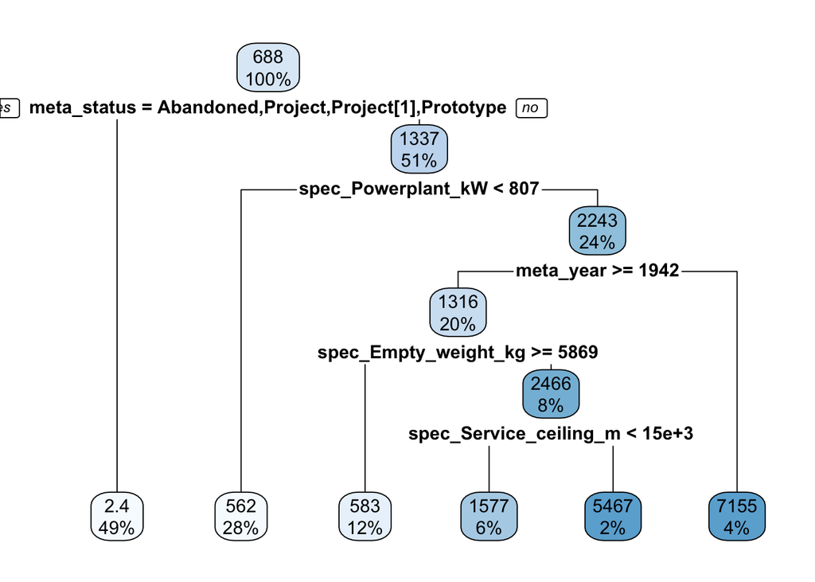

```r
rpart.plot(mod)
```

## So why was that easy?

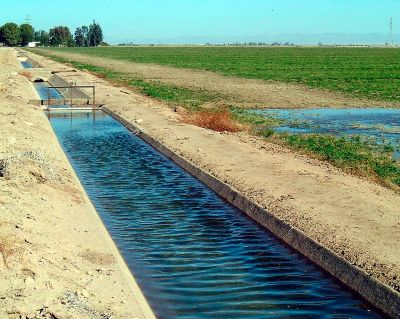

## Because each observation is discreet

Things get a lot, lot harder when:

- You’re working with evolving states
- Hence sequence matters
- and you need to look down columns, not just across rows

```r
df_master %>%
  arrange(desc(meta_country), (meta_year)) %>%
  select(name, meta_country, meta_number, meta_year, meta_status, spec_Powerplant_kW, spec_Empty_weight_kg) %>%
  head(n = 20)
```

```
## # A tibble: 20 x 7
##    name  meta_country meta_number meta_year meta_status spec_Powerplant…
##    <chr> <chr>              <dbl>     <dbl> <chr>                  <dbl>
##  1 Poli… USSR                  18      1923 Abandoned               298.
##  2 Grig… USSR                   1      1924 Abandoned               298.
##  3 Tupo… USSR                 369      1927 Retired                  NA
##  4 Poli… USSR                 389      1928 Retired                 544.
##  5 Tupo… USSR                   1      1930 Abandoned               466.
##  6 Grig… USSR                   1      1931 Abandoned               544.
##  7 Grig… USSR                  73      1931 Retired                 358.
##  8 Tupo… USSR                   1      1931 Abandoned               391.
##  9 Lavi… USSR                   1      1932 Abandoned               447.
## 10 Poli… USSR                 671      1933 Retired                 353.
## 11 Poli… USSR                8644      1933 Retired                 820.
## 12 Tupo… USSR                  20      1933 Retired                  NA
## 13 Koch… USSR                 222      1934 Retired                 522.
## 14 Poli… USSR                   3      1934 Abandoned               641.
## 15 Boro… USSR                   8      1937 Abandoned               671.
## 16 Poli… USSR                2408      1937 Retired                 353.
## 17 Poli… USSR                   3      1938 Abandoned               353.
## 18 Poli… USSR                3437      1938 Retired                 597.
## 19 Poli… USSR                  13      1938 Abandoned               820.
## 20 Poli… USSR                   2      1939 Abandoned               597.
## # … with 1 more variable: spec_Empty_weight_kg <dbl>
```

## Features look like:

(Taking a customer churn model as a case in point)

- When did this customer first open their account?
- How old is the account?
- How many times in the last 6 months have they made this type of enquiry?
- What is the total number of transactions last month?
- How long since they the last…?
- Have they ever…?
- What is their ‘usual’ pattern for…?

## Some thoughts on how to manage this

- Use purrr. Nest your data-frames.
- Keep pipes separate as long as possible, join at a known time-bin
- Figure out how large a look-back is required for next increment of data
- Use rolling counts/increments
- Write a loop to re-iterate increments for the whole time-period, rather than assumming all data available.

Here’s how to nest

```r
ftplanes_n  <- ftplanes %>%
  arrange(country, year, number) %>%
  group_by(country) %>%
  nest()
head(ftplanes_n)
```

```
## # A tibble: 6 x 2
##   country                 data
##   <chr>                   <list>
## 1 Australia               <tibble [2 × 28]>
## 2 Austro-Hungarian Empire <tibble [3 × 28]>
## 3 Belgium                 <tibble [2 × 28]>
## 4 Canada                  <tibble [1 × 28]>
## 5 Chile                   <tibble [1 × 28]>
## 6 China (PRC)             <tibble [9 × 28]>
```

```r
ftplanes_n <- ftplanes_n %>%
  mutate(serving_planes = data %>% map(~ .x %>% filter(status == "Operational")),
         size_current_airforce = serving_planes %>% map_dbl(~ .x  %>% pull(number) %>% sum()))
head(ftplanes_n)
```

```
## # A tibble: 6 x 4
##   country              data            serving_planes   size_current_airfo…
##   <chr>                <list>          <list>                         <dbl>
## 1 Australia            <tibble [2 × 2… <tibble [0 × 28…                   0
## 2 Austro-Hungarian Em… <tibble [3 × 2… <tibble [0 × 28…                   0
## 3 Belgium              <tibble [2 × 2… <tibble [0 × 28…                   0
## 4 Canada               <tibble [1 × 2… <tibble [0 × 28…                   0
## 5 Chile                <tibble [1 × 2… <tibble [1 × 28…                  15
## 6 China (PRC)          <tibble [9 × 2… <tibble [7 × 28…                3734
```